### Page Head Redesign

Due to the nature of the design relying on white space to generate a polaroid effect, and the use of white space to seperate information and navigation I had to take another take on this as I won't have control over the text length generated by users. The text length has the potentional to fit in line with the white space of the design and the different display break points that are available. In the process of building the page head I came accross the toggle div-display option which I see as a positive feature to put more emphasis on the display of images.

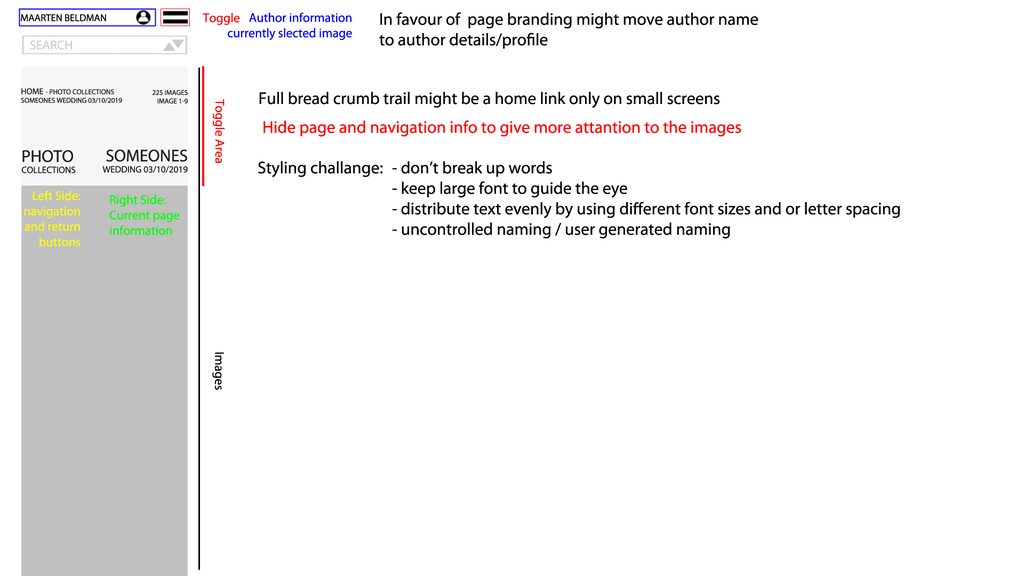

# Info toggle

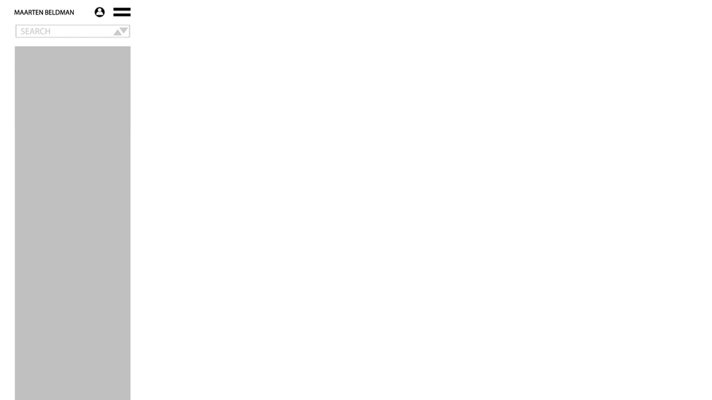

# mobile / col

H3 plus creative text layout  
Author contact details are clickable (profile) icon

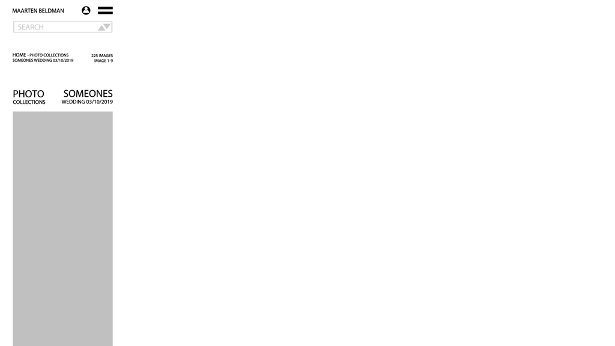

# col - sm breakpoint

H2 plus creative text layout  
Author contact details are clickable (profile) icon

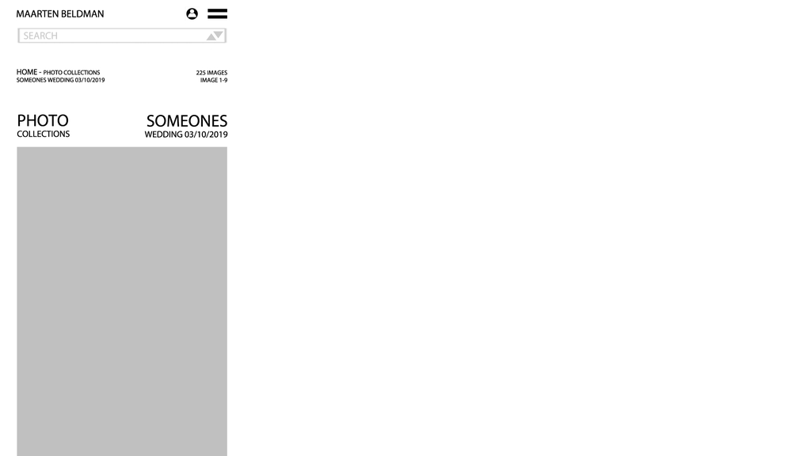

# sm - md breakpoint

H1 plus creative text layout  
Page information text font size increase  
Author contact details are clickable (profile) icon

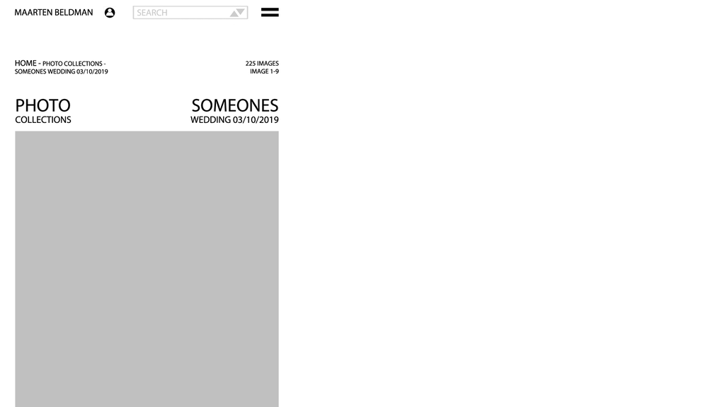

# md - lg breakpoint

H1 plus creative text layout  
Author contact details are clickable (profile) icon

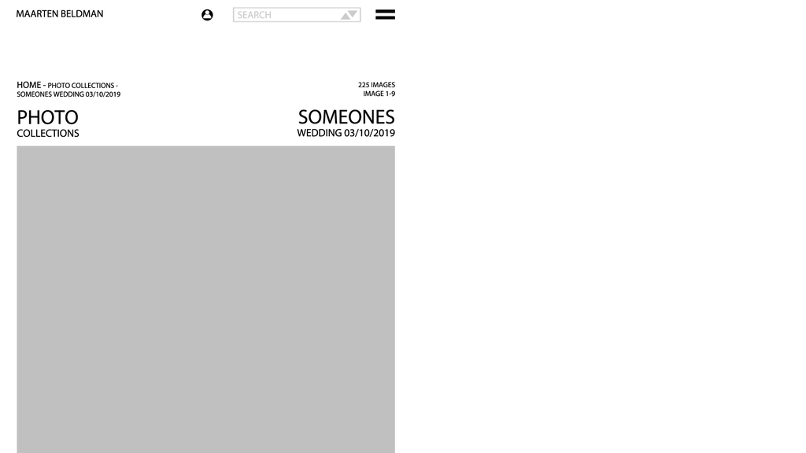

# lg - xl breakpoint

H1 becomes H2 if not enough white space  
Author contact details are text (button to profile or contact)

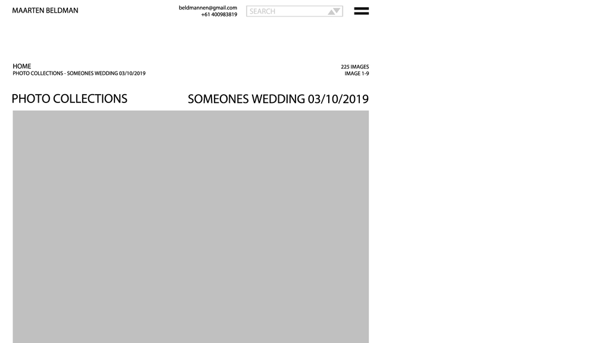

# xl full width

H1

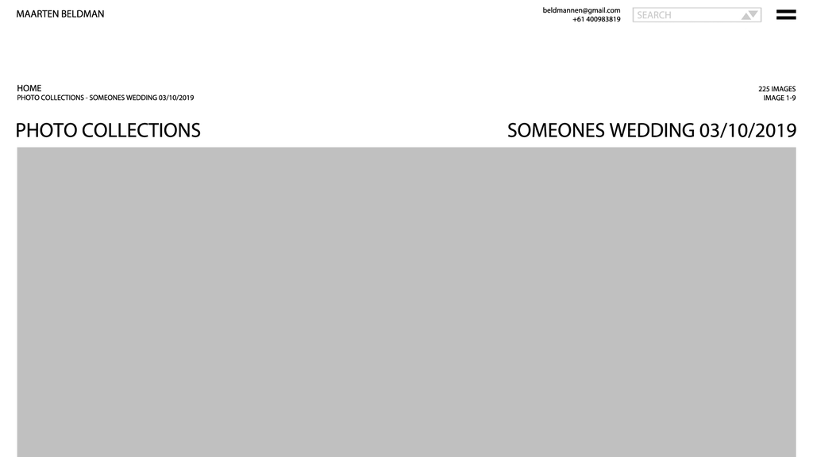